# PISA 2012 Exploration

## by Maryse Bonhomme

## Overview

> PISA is the [OECD's](https://en.wikipedia.org/wiki/OECD) Program for International Students Assessment. The goal of the Program is to assess 15 years old in order to evaluate their skills in Math, Reading and Science. And more importantly to evaluate how prepared to the future they are by asking all sort of questions. The Survey is done by PISA every 3 years, and assess various areas of the 15 years old. They assess the students life both inside school and out of school, including at home. Asking questions about possessions, family context and even how much time the students spend on their computers.

> The dataset that will be used today for analysis is the PISA 2012 survey, with participants from 65 countries.we are using the responses given by the students. The results is a huge dataset with more than 636 variables and responses from almost 510, 000 students ( 485490 rows are part of this dataset).

### Analysis Questions

The dataset covers a broad areas of the 15 years old's lives. As part of the analysis today, I will focus on the following questions:

1. In which Subjects are students getting better scores?
   - In general, do students tends to succeed more in one subject and not the others?
   - Do OECD and Non_OECD perform the same in the tests?
   - On Math, Reading and Science tests, do boys and girls perform the same? is the score distribution the same?
2. Time spent on computers and Scores
   - How does the time spent on computer affect students scores? does it even have any impact on the student's score?
   - Is it the same for students of both genders?
   - Is it the trend the same in both OECD and non OECD countries?

## Univariate Exploration

> As specified in our research questions earlier, now we are going to analyze :
> - Secton 1: The proportions of our group of interests, OECD, Non_OECD, boys and girls.
> - Section 2: The math, reading and science scores. we will also mostly try to understand the scores distributions.
> - Section 3: Do a preliminary of exploration of the variable Computer_time that describes how much time the students spends on a computer in minutes.

### Visualization 1

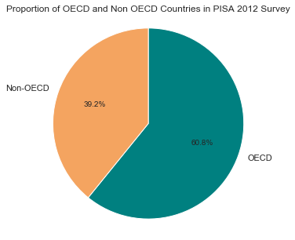

```python
# code for the pie chart seen above
sorted_counts = df_clean['OECD'].value_counts()
colors = ['#008080', '#F4A460']
plt.pie(sorted_counts, labels = sorted_counts.index, startangle = 90,autopct='%1.1f%%',colors=colors,
        counterclock = False);
plt.title('Proportion of OECD and Non OECD Countries in PISA 2012 Survey')
plt.axis('square');
```

#### Proportions of OECD and Non OECD Countries that participated in the survey

> As I was getting familiar with the dataset, It seemed interesting to know the proportions of OECD and Non_OECD Countries participants in the survey. there are clearly much more OECD countries participants as they accounts for 60.8% of the survey's participants. But that is not really surprising as the PISA , the organizer of the survey is a part of the OECD.

### Visualization 2

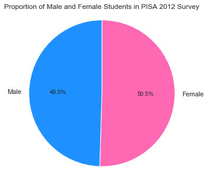

```python
# code for the pie chart seen above
sorted_counts = df_clean['gender'].value_counts()
colors = ['#FF69B4','#1E90FF']
plt.pie(sorted_counts, labels = sorted_counts.index, startangle = 90,autopct='%1.1f%%',colors=colors,
        counterclock = False);
plt.title('Proportion of Male and Female Students in PISA 2012 Survey')
plt.axis('square');
```

## Proportion of Boys and Female Students in the survey

### Visualization 3

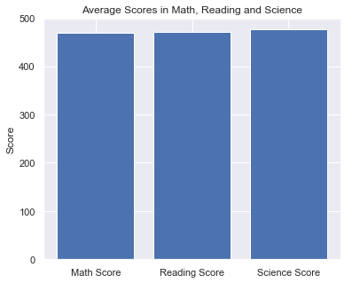

```python
plt.figure(figsize=[6,5])
# plotting Math, Reading and Science Score to see if children tends to succeed more in one
labels = ["Math Score", "Reading Score", "Science Score"]
usage = [df_clean['math_average'].mean(),df_clean['reading_average'].mean(), df_clean['science_average'].mean()]

# Generating the y positions. Later, we'll use them to replace them with labels.
y_positions = range(len(labels))

# Creating our bar plot
plt.bar(y_positions, usage)
plt.xticks(y_positions, labels)
plt.ylabel("Score")
plt.title("Average Scores in Math, Reading and Science")
plt.show()
```

#### In general, Students Equally Succeed(or fail) in the field of Math, Reading and Science

> My primary assumption would have been that students succeed more in one subject comparing to others. For example that they will do better in Reading for example, but in general I see that, based on this survey, students tend to equally succeed (or fail) in all 3 subjects. The mean scores in Math, Reading and Science is the almost the same. the mode is is also very close to the mean and remain almost the same in all 3 subjects.  
> There is no subject where the average score is significantly higher or smaller than the others. It is important to quickly notice that the mean values are slightly below the average of 500. the test are scored on a 1000.

### Visualization 4

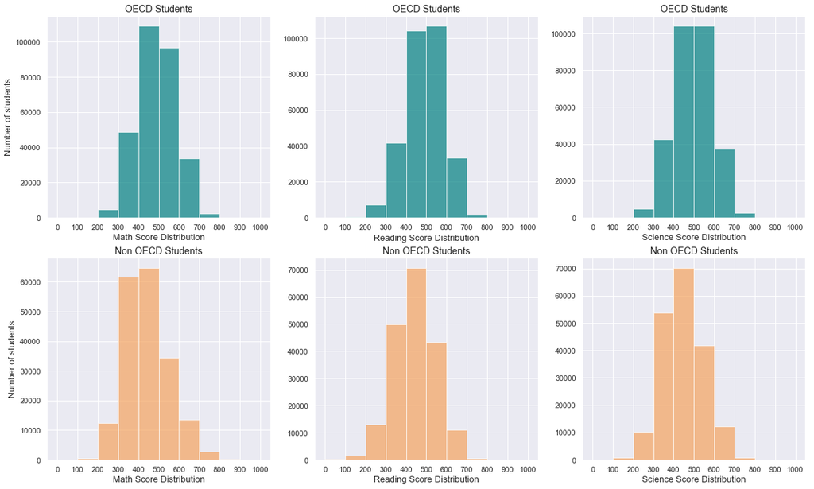

```python
plt.figure(figsize = [20, 12])

bins_hist = np.arange(0, 1000 + 1, 100)
# 1st row  (OECD Countries)
plt.subplot(2, 3, 1)
color_OECD=['#008080']
color_NOECD = ['#F4A460']
xylabel = 13
title =14
plt.hist(OECD['math_average'], bins = bins_hist, alpha = 0.7, color=color_OECD);

plt.xticks(bins_hist)
plt.xlabel('Math Score Distribution',fontsize=xylabel);
plt.ylabel('Number of students',fontsize=xylabel)
plt.title("OECD Students", fontsize=title);

plt.subplot(2, 3, 2)
plt.hist(OECD['reading_average'], bins = bins_hist,  alpha = 0.7, color=color_OECD);

plt.xticks(bins_hist)
plt.xlabel('Reading Score Distribution',fontsize=xylabel);
plt.title("OECD Students",fontsize=title);

plt.subplot(2, 3, 3)
plt.hist(OECD['science_average'], bins = bins_hist, alpha = 0.7, color=color_OECD);

plt.xticks(bins_hist)
plt.xlabel('Science Score Distribution',fontsize=xylabel);
plt.title("OECD Students",fontsize=title);

# 2nd row (Non OECD Countries)

plt.subplot(2, 3, 4)

plt.hist(Non_OECD['math_average'], bins = bins_hist, alpha = 0.7, color=color_NOECD);

plt.xticks(bins_hist)
plt.xlabel('Math Score Distribution',fontsize=xylabel);
plt.ylabel('Number of students',fontsize=xylabel)
plt.title("Non OECD Students", fontsize=title);

plt.subplot(2, 3, 5)
plt.hist(Non_OECD['reading_average'], bins = bins_hist,  alpha = 0.7, color=color_NOECD);

plt.xticks(bins_hist)
plt.xlabel('Reading Score Distribution',fontsize=xylabel);
plt.title("Non OECD Students",fontsize=title);

plt.subplot(2, 3, 6)
plt.hist(Non_OECD['science_average'], bins = bins_hist, alpha = 0.7, color=color_NOECD);

plt.xticks(bins_hist)
plt.xlabel('Science Score Distribution',fontsize=xylabel);
plt.title("Non OECD Students",fontsize=title);
```

#### Math, Reading and Science Score Distribution for OECD and Non OECD Countries

- Math Score: A big part of OECD countrie's students have a math score between 400 and 600. For the Non OECD Countries, we can see that the average is lower where a big part of Non OECD Countries have a Math Score between 300 and 500.  
  It is also very interesting to observe that Non OECD countries have a bigger proportion of top students in Math (Score between 700 and 800) than the OECD Countries. But the opposite is also true , the number of students with really lower scores (between 100 and 300) is much higher in Non OECD countries.
- Reading Score: For the OECD Countries an important portion of students had score between 400 and 600. with Non OECD Countries, the distribution is much more dispersed. but at the opposite of math score, Non OECD countries have less top students than OECD Countries. but in the score range between 100 and 300, we can see that the proportion of Non OECD countries is much more important than those of OECD Countries.
- Science Score: As with other subjects, the OECD Countries have a more centered distribution with most students having a score between 400 and 600. the tendency of Non OECD countries as with other subject is more dispersed. but for science score, the OECD has more top students than Non OECD Countries.

### Visualization 5

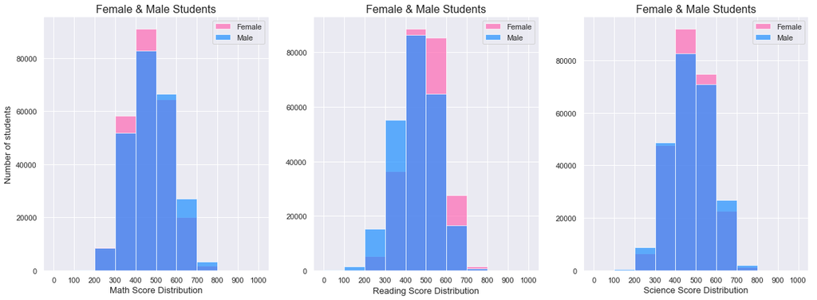

```python
plt.figure(figsize = [20, 15])

bins_hist = np.arange(0, 1000 + 1, 100)
# 1st row  (OECD Countries)
plt.subplot(2, 3, 1)
color_girls= ['#FF69B4']
color_boys = ['#1E90FF']
alpha = 0.7
xylabel = 13
title =16
label = 'Female'
plt.hist(female['math_average'], bins = bins_hist, alpha = alpha, color=color_girls);
plt.hist(male['math_average'], bins = bins_hist, alpha = alpha, color=color_boys);

plt.xticks(bins_hist)
plt.ylabel('Number of students', fontsize=xylabel)
plt.title("Female & Male Students", fontsize=title);
plt.legend([ "Female", "Male"])

plt.xlabel('Math Score Distribution', fontsize=xylabel);
plt.subplot(2, 3, 2)
plt.hist(female['reading_average'], bins = bins_hist,  alpha = alpha, color=color_girls);
plt.hist(male['reading_average'], bins = bins_hist,  alpha = alpha, color=color_boys);
plt.xticks(bins_hist)
plt.xlabel('Reading Score Distribution', fontsize=xylabel);
plt.title("Female & Male Students", fontsize=title);
plt.legend([ "Female", "Male"])

plt.subplot(2, 3, 3)
plt.hist(female['science_average'], bins = bins_hist, alpha = alpha, color=color_girls);
plt.hist(male['science_average'], bins = bins_hist, alpha = alpha, color=color_boys);
plt.xticks(bins_hist)
plt.xlabel('Science Score Distribution', fontsize=xylabel);
plt.title("Female & Male Students", fontsize=title);
plt.legend([ "Female", "Male"]);
```

#### Scores Distribution for Girls and Boys

> - In Math we can see that the score distribution tend to be the same for both female and male students. the number of female students in the range of 300 and 500 is bigger. while in the score range between 500 and 800, the number of male students is more important. Meaning that in mathematics, we have more male top students.
> - The shape of the Reading score distribution also tend to be the same for both genders. but in the score range between 400 and 800, female students seems to have higher. simply meaning that you have more top female students in Reading. while the number of male student with lower scores (between 100 and 400) is much more important compared to the proportion of female students in the same group.
> - Female students tends to do well in Science. but the proportion of top male students is bigger. equally, the proportion of students with lower score is also more important among male students. overall the number of female students tends to be higher in the range between 400 and 600.

### Section 3: Time (in minutes) Students Spend on a computer

### Visualization 6

[figure not shown]

```python
plt.figure(figsize = [20, 10])
color_OECD='#008080'
color_NOECD = '#F4A460'

bins_hist = np.arange(0,210, 10)
# 1st row
plt.subplot(2, 2, 1)
ax = sb.boxplot(x=OECD['Computer_time'], color=color_OECD).set_title('OECD Countries')

plt.subplot(2, 2, 2)
ax = sb.boxplot(x=OECD['Computer_time'], color=color_NOECD).set_title('Non OECD Countries')
```

### Visualization 7

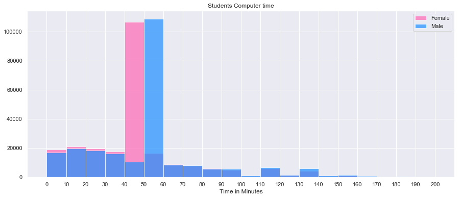

```python
plt.figure(figsize = [15, 6])

color_girls= '#FF69B4'
color_boys = '#1E90FF'

bins_hist = np.arange(0,210, 10)
plt.hist(female['Computer_time'], bins = bins_hist, alpha = 0.7, color=color_girls);
plt.hist(male['Computer_time'], bins = bins_hist, alpha = 0.7, color=color_boys);
plt.xticks(bins_hist)
plt.xlabel('Time in Minutes');
plt.title("Students Computer time")
plt.legend(["Female", "Male"]);
```

#### Male and Female Students computer time distribution

> For the visualization of the amount of time spent on the computer by both female and male students, I chose this plot because the two groups proportions are equal. so we can see that two groups distributions is almost the same but
> - a big portion of female students seems to spend somewhere between 40 and 50 minutes on computer
> - a big portion of male students seems to spend somewhere between 50 and 60 minutes on computer

## Bivariate Exploration

> In this section, I will do the following analysis:
> - Do a comparison of averages scores for my groups of interests, in each subject (Math, Reading and Science)
> - Study the relationship between time spent on computer and the average score obtained by the students.  
>   I will still be comparing OECD to Non OECD countries and Female and male students.

### Visualization 8

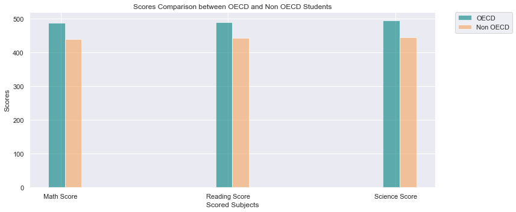

```python
n_groups = 3

OECD_scores = (488.4012368806699, 490.79673282096957, 494.9216082561551)
Non_OECD_scores = (440.5096842789633, 442.80361003051013, 446.1015696309864)

fig, ax = plt.subplots()

index = np.arange(n_groups)
bar_width = 0.1
opacity = 0.6

rects1 = plt.bar(index, OECD_scores, bar_width, alpha=opacity, color=color_OECD,label='OECD')
rects2 = plt.bar(index + bar_width,Non_OECD_scores, bar_width, alpha=opacity, color=color_NOECD, label='Non OECD')

rcParams['figure.figsize'] = 12,4

ax.set_xlabel('Scored Subjects')
ax.set_ylabel('Scores')
ax.set_title('Scores Comparison between OECD and Non OECD Students')
ax.set_xticks(index + bar_width / 4)
ax.set_xticklabels(('Math Score', 'Reading Score', 'Science Score'))

ax.legend(bbox_to_anchor=(1.05, 1), loc=2, borderaxespad=0.)
fig.tight_layout()
plt.show ()
```

#### Scores Comparison between OECD and Non OECD Countries For Math, Reading and Science

> In General we can see that in all 3 subjects where students were tested, OECD countries consistently do better than Non OECD countries.  
> This confirms what we have previously seen while plotting the scores distribution in the univariate analysis section

### Visualization 9

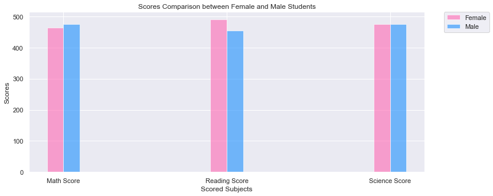

```python
n_groups = 3

male_scores = (475.3493465528562, 453.9525261445896, 476.27639791470205)
female_scores = (464.06096174738224, 489.71970972947065, 475.3486531093991)

fig, ax = plt.subplots()

index = np.arange(n_groups)
bar_width = 0.1
opacity = 0.6

rects1 = plt.bar(index, female_scores, bar_width, alpha=opacity, color=color_girls,label='Female')
rects2 = plt.bar(index + bar_width,male_scores, bar_width, alpha=opacity, color=color_boys, label='Male')

rcParams['figure.figsize'] = 12, 6

ax.set_xlabel('Scored Subjects')
ax.set_ylabel('Scores')
ax.set_title('Scores Comparison between Female and Male Students')
ax.set_xticks(index + bar_width / 2)
ax.set_xticklabels(('Math Score', 'Reading Score', 'Science Score'))

ax.legend(bbox_to_anchor=(1.05, 1), loc=2, borderaxespad=0.)
plt.show ()
```

#### Scores Comparison between Female and Male Students

> when we compare the mean scores:
> - Male students slightly to better than female students in Math.
> - In the Reading test, female students did better than male students
> - Lastly, In the science test, the male and female scores are equal

### Visualization 10

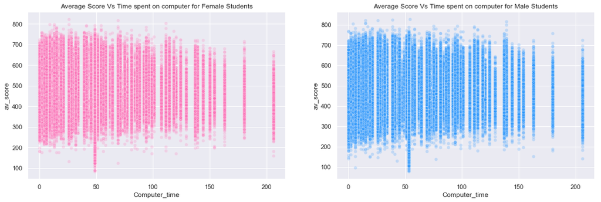

```python
plt.figure(figsize = [18, 12])
plt.subplot(2,2, 1)
ax = sb.scatterplot(y="av_score", x="Computer_time",  alpha=0.2, data=female, color=color_girls).set_title('Average Score Vs Time spent on computer for Female Students')
plt.subplot(2, 2, 2)
ax = sb.scatterplot(y="av_score", x="Computer_time",  alpha=0.2, data=male, color=color_boys).set_title('Average Score Vs Time spent on computer for Male Students')
```

### Visualization 11

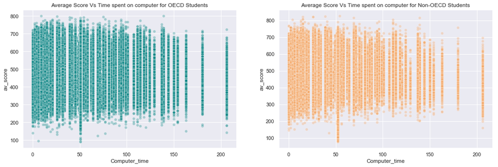

```python
plt.figure(figsize = [18, 12])
plt.subplot(2, 2, 3)
ax = sb.scatterplot(y="av_score", x="Computer_time",  data=OECD,alpha=0.3, color=color_OECD).set_title('Average Score Vs Time spent on computer for OECD Students')
plt.subplot(2, 2, 4)
ax = sb.scatterplot(y="av_score", x="Computer_time",  data=Non_OECD,alpha=0.3, color=color_NOECD).set_title('Average Score Vs Time spent on computer for Non-OECD Students')
```

#### Relationship Between Time Spent on Computers and Scores

> In order to simplify this task, I made an average score of the 3 subjects. The objective being to understand if spending more or less time on the computer has any effects on marks. It seems like, based on the data we have, that the time spent on the computer doesn't really affect the scores. students who spent very little computer time are as likely to get really good scores or really bad one.  
> It's also seems from 150 minutes of time spent on the computer, the concentration of top students (score above 700) really goes down.  
> The tendency doesn't vary much across our 4 groups. The time spent on computer doesn't have an effect on the scores.

## Bivariate Exploration Summary:

> - In average, OECD countries consistently do better than Non OECD countrie in all 3 subjects
> - Male students in average did a little bit better than female students in the test math
> - female student did better than male students in reading
> - both genders had the same average scores in science test
> - the time the students spend on their computer doesn't really affect their scores, even if above 150 minutes of time spent on the computer, the concentration of top students (above 700) really diminish.

## Multivariate Exploration

> In this section,I am going to do a Pair plot, continuing the comparison of the math, reading and sciences scores across our groups of interest.

### Visualization 12

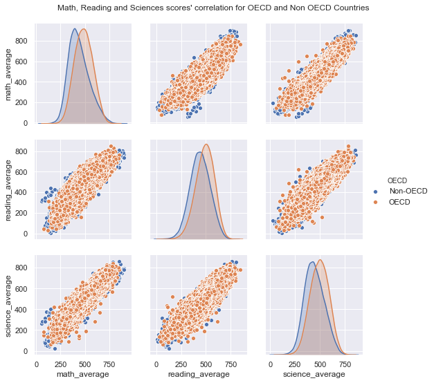

```python
g = sb.pairplot(data = df_clean, height=2.5, vars = ['math_average', 'reading_average', 'science_average'], hue="OECD");
g.fig.suptitle("Math, Reading and Sciences scores' correlation for OECD and Non OECD Countries", y = 1.02);
```

### Visualization 13

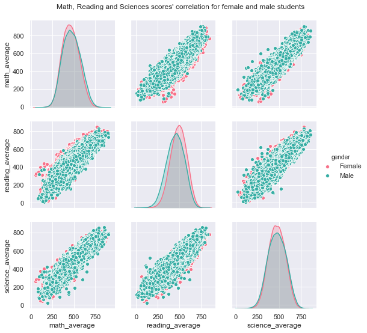

```python
g = sb.pairplot(data = df_clean, height= 2.5, vars = ['math_average', 'reading_average', 'science_average'], hue="gender", palette="husl")
g.fig.suptitle("Math, Reading and Sciences scores' correlation for female and male students", y = 1.02);
```